# Time Series Prophet

Time series forecasting project in R using Meta Prophet on IBM closing price data

Kesaagini Kugathasan

Spring term 2026

# Section 1: Introduction

## 1.1 Project Overview

The purpose of this project is to examine IBM stock price data using Prophet in R.  
First, the original time series is plotted to give an initial view of how the share price changes over time. The data is then prepared in the format required by Prophet and the forecasting model is fitted. A 30-period forecast is produced and the output plots are used to comment on the future pattern of the series. This gives a simple overview of how Prophet can be used to analyse and forecast financial time series data.

[figure not shown]

## 1.2 Data Source

The data used in this project was sourced from Macrotrends, which provides historical stock price data. For this analysis, IBM closing price data was downloaded and imported into R for forecasting. The dataset contains the variables date, open, high, low, close and volume. In this project, the main focus is on the date and close variables, since the closing price is the value being forecast.

# Section 2: Data Preparation

## 2.1 Loading the Package and Data

Before fitting the forecasting model, the IBM data first needs to be loaded into R and set up in a way that Prophet can use. The prophet package was loaded into R before starting the analysis. The dataset was then imported and the first few rows were checked using ‘head()’ to confirm that it had loaded correctly. The date column was then converted into Date format so that R could recognise it as a time variable.

```r
library(prophet)
ibm_data = read.csv("Data/ibm_data.csv")
head(ibm_data)
```

```
##         date   open   high    low  close volume
## 1 02/01/1962 1.5090 1.5090 1.4921 1.4921   3991
## 2 03/01/1962 1.4922 1.5052 1.4922 1.5052   2993
## 3 04/01/1962 1.5052 1.5052 1.4895 1.4902   2686
## 4 05/01/1962 1.4882 1.4882 1.4582 1.4608   3760
## 5 08/01/1962 1.4595 1.4595 1.4217 1.4334   5602
## 6 09/01/1962 1.4400 1.4687 1.4400 1.4504   5065
```

```r
ibm_data$date = as.Date(ibm_data$date, format = "%d/%m/%Y")
ibm_data = ibm_data[order(ibm_data$date), ]
```

## 2.2 Plot of Original Time Series

This code produces a time series plot of IBM stock prices over time. The dates are shown on the x-axis and the stock prices are shown on the y-axis. The ‘type = “l”’ joins the observations with a line, which makes it easier to see how the series moves over time. The other parts of the code simply add a title and labels to the axes.

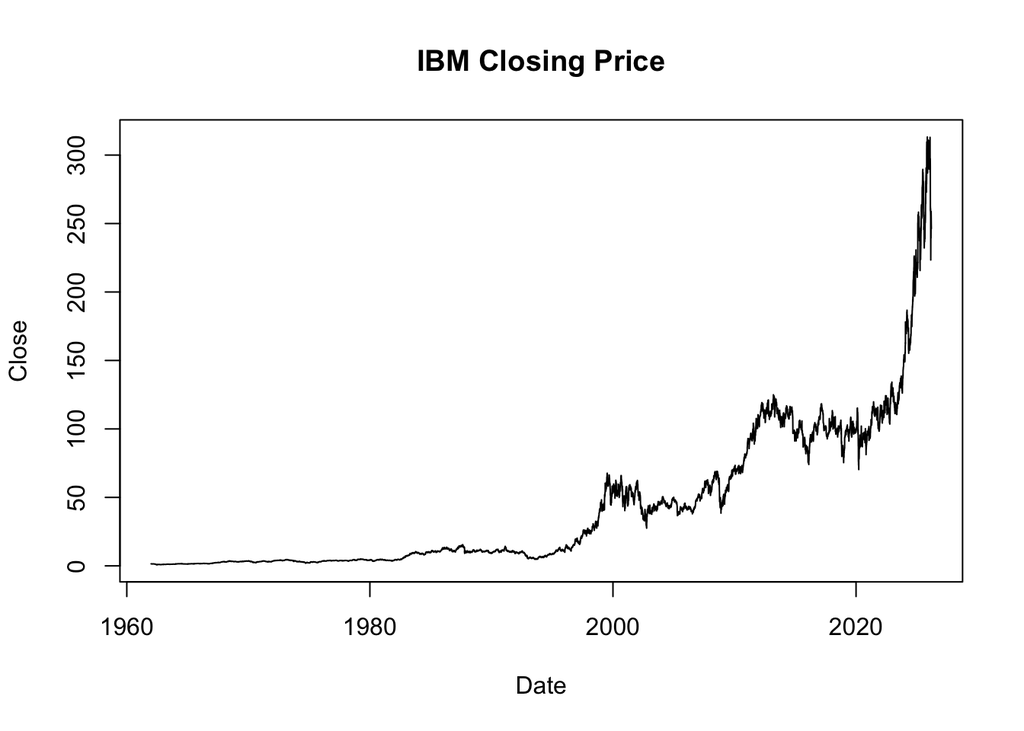

```r
plot(ibm_data$date, ibm_data$close, type = "l",
     main = "IBM Closing Price",
     xlab = "Date",
     ylab = "Close")
```

This plot gives an initial view of IBM closing prices over time. The series shows clear variation, but there is also an overall upward movement across the sample. In the earlier part of the series, the closing price stays fairly low and moves more steadily. Later on, the changes become larger and the price rises more quickly. This shows that the series does not stay the same over time, so it makes sense to explore it further using a forecasting model.

## 2.3 Preparing Data for Prophet

Before fitting the model, the data must be placed into the format required by Prophet. This means that the date column must be named ‘ds’ and the variable being forecast must be named ‘y’. A new data frame is therefore created using the IBM date values and closing prices.

```r
ibm_prophet_data = data.frame(
    ds = ibm_data$date,
    y = ibm_data$close
 )
```

This makes sure the dataset is suitable so that it can be used directly in the Prophet model.

# Section 3: Fitting the Prophet Model

After preparing the data, the Prophet model is fitted using the ‘prophet()’ function. This creates the forecasting model that will be used to generate future values for the IBM closing price series.

```r
ibm_prophet_model = prophet(ibm_prophet_data)
```

# Section 4: Forecasting Future Values

After fitting the model, future dates can be created and forecasts can be produced. The ‘make_future_dataframe()’ function is used to extend the time series forward by 30 periods. The ‘predict()’ function is then used to generate forecast values from the fitted model.

```r
ibm_future_dates = make_future_dataframe(ibm_prophet_model, periods = 30)

ibm_forecast = predict(ibm_prophet_model, ibm_future_dates)
```

This step produces the forecast values that are used in the next stage of the analysis.

# Section 5: Forecast Plot

The forecast can now be displayed using a plot. This graph shows the observed data together with the values produced by the Prophet model.

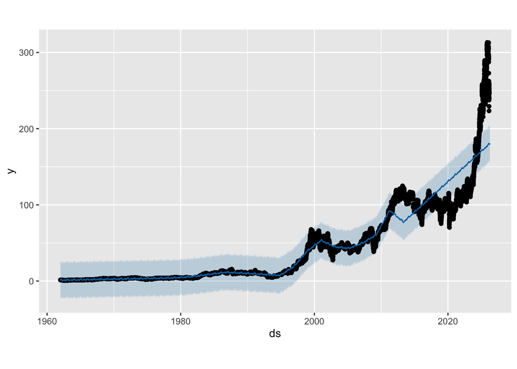

```r
plot(ibm_prophet_model, ibm_forecast)
```

# Section 6: Forecast Components

The Prophet model can also break the forecast into separate components. This makes it easier to see the main patterns that the model has identified in the data.

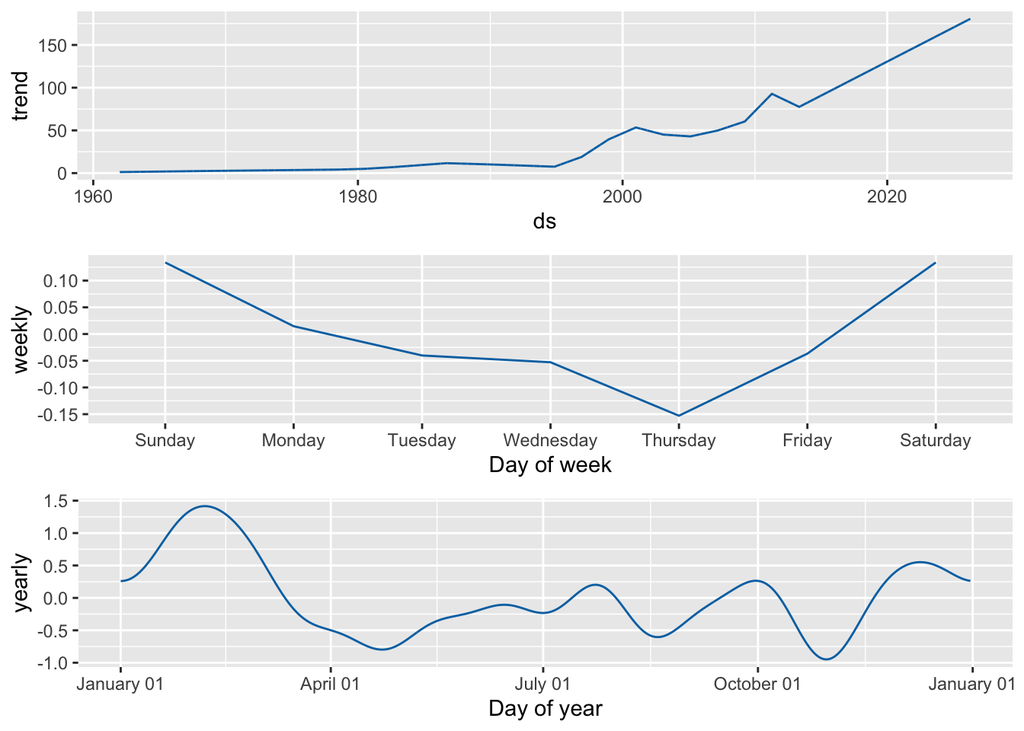

```r
prophet_plot_components(ibm_prophet_model, ibm_forecast)
```

The components plot shows the trend, weekly effect and yearly effect in the fitted model. The trend increases overall across the sample, although there are some periods where the growth slows down or falls slightly before rising again. The weekly effect is fairly small, with Sunday and Saturday showing the most positive values, while Thursday appears to have the most negative effect. The yearly pattern also shifts over time, with some parts of the year having a more positive effect than others. Overall, the trend stands out the most in the model, while the weekly and yearly patterns are there but much less noticeable.

# Section 7: Conclusion

In this project, IBM closing price data was analysed using Prophet in R. The original time series showed a large amount of variation, which made it clear that the data did not remain constant over time. After preparing the dataset in the format required by Prophet, a forecasting model was fitted and used to produce future values and component plots.

The forecast plot suggested that the model was better at capturing the general level of the series than the short term movements. This is important because stock price data can change quickly, so it is difficult for a simple model to follow every rise and fall closely. The components plot also helped to break the forecast into separate parts. From this, the yearly effect appeared more noticeable than the weekly effect, while the overall trend showed a clear upward movement over time.

Overall, this project provided a useful introduction to time series forecasting with Prophet.It showed how raw stock price data can be imported, prepared, modelled and interpreted in R. Although the forecast should be treated with caution, the analysis still gave a helpful overview of the structure of the series and how forecasting methods can be applied to financial data.

# References

- Historical Stock Price Data for IBM : https://www.macrotrends.net/
- Meta Prophet forecasting procedure: https://facebook.github.io/prophet/docs/quick_start.html#r-api